# Neural Networks Lab

In this lab, we'll be exploring a visual proof of the universal approximation theorem and building (from scratch) a neural network that will approximate a pretty ridiculous function.

Head over to [this site](http://neuralnetworksanddeeplearning.com/chap4.html) and read from the beginning of the page until the "Many Input Variables" section. (You do not need to read the "Many Input Variables" section and beyond but are certainly welcome to do so!) You'll read the introduction, the "Two Caveats" section, and the "Universality with One Input and One Output" section.

Your answers to problems 1-5 should come from directly this reading.

**Problem 1**: Summarize the Universal Approximation Theorem. (Don't copy it; use your own words!)

The Universal Approximation Theorem says that neural networks can estimate the output of any mathematical function, no matter how many inputs that function takes or how many possible ouputs it may produce. Even a neural network with a single layer can provide pretty good estimates*, but often a neural network with a larger hidden layer and/or more hidden layers will do even better. Since basically any process can be described as a mathematical function, neural networks can, in theory, predict the outcome of basically any process pretty well. In practice, a neural network must have the right size and level of complexity to 'learn' a complex process, and it must be trained correctly.

*The theorem actually says that a single hidden layer is all that is required to provide a good approximation.

**Problem 2**: Summarize the two caveats the author uses to describe the statement "a neural network can compute any function."

The first caveat is obvious: a neural network cannot compute any function, it can only *approximate* it, which is just another way of saying it will provide a pretty good guess of what the function would output for a given input or set of inputs.

The second caveat is not obvious, but its also not too important most of the time. It says that a neural network can only really approximate a continuous function, since neural networks themselves have continuous output. If a function has undefined outputs in a given range, or if its ouput jumps wildly from point to point, then a neural network isn't guaranteed to deliver a decent approximation.

**Problem 3:** For a sigmoidal activation function to closely resemble a step function, how would you describe the value of $w$? What constraints exist on the value of $b$? How do we calculate $s$? What does the value of $s$ indicate?

Try playing around with the applets on the page to test how different parts of the perceptron affect the output. This should be helpful in answering the questions above.

The weight `w` coming in must be very high. The higher `w`, the lower the bias `b` must be so that the 'step' between ouput 0 and output 1 occurs in the range (0,1). The lower the bias, the higher the value of `x` must be before the step occurs. This makes sense, since the purpose of the bias is to control the level of activation of a node given little or no input. The higher the weight, the lower the value of `x` must be in ordert to hit the 'step' and trigger activation of the node. This makes sense, since the node's inputs will have a greater linear effect on the activation of the node. (And we are here dealing with only positive inputs in the range (0,1).)

Since we're working with a sigmoid function with such a high weight that is an approximation of a step function, we can parameterize our hypothetical step function with `s`, which just gives the location of the step between 0 and 1. It is `s = -b/w`.

*The text says `s` is proportional to `b` and inversely proportional to `w`. That's not really true, though, is it? It is proportional to `-b`, not `b`. Oh wait, nevermind. Proportional to `-b` is the same as proportional to `b`. Proportionality doesn't require two variable move in the same direction, just that they exhibit a constant relationship.

**Problem 4**: When the author wants us to approximate $f(x)=0.2+0.4x^2+0.3x\sin(15x)+0.05\cos(50x)$ with a neural network, the function on the applet where we manipulate the values of $h_i$ is not $f(x)$. It's a different function. What is this function, and why are we working with this one instead of $f(x)$?

Previously, we adjusted parameters to show different values for the weighted output from the hidden layer. But even with only a single output neuron, that is not what our network outputs! The final output neuron has a bias of its own, and an activation function. To abstract away from that, we were manipulating `h` to approximate f(x) with the inverse of the activation applied and without any bias term. This *other* function is just the answer to the question: what function do we want the weighted output `Z` of our hidden layer to approximate so that once we apply a sigmoid activation function (and no bias) to `Z` we will arrive at an approximation of f(x)?

**Problem 5**: The author asks you to find values of $h_i$ that make your neural network closely approximate $\sigma^{-1}\circ f(x)$. Record your values of $h_i$ here and your best "average deviation" score.

h1 = -1.2

h2 = -1.6

h3 = -0.3

h4 = -1.0

h5 = 1.0

average deviation = .38

I *think* .38 is the best one can do.

**Problem 6**: Build the neural network from your work in Problem 5 here.

A few things to keep in mind:

- How many inputs are there?
- How many outputs are there?
- How many neurons are in the hidden layer?
- In order to create step functions between 0 and 0.2, 0.2 and 0.4, etc., what does this suggest about the activation function in these neurons? Note that these activation functions will be different, but related.
- What do the values of $h_i$ represent?

Check out the [Neural Networks I notes](https://git.generalassemb.ly/DSI-DC-5/5.09-neural-networks-i/blob/master/5.09-neural-networks-i.ipynb) for an implementation in NumPy; you should be able to use this as a starting point for your model.

- Number of inputs: 1 input node
- Number of outputs: 1 output node
- Number of nodes in hidden layer: 5 pairs * 2 per pairs = 10 nodes
- We need different activation functions *if* we are using the step function, because we want steps at different points. If we are using the sigmoid activation with a high weight, we don't need different activation functions! Just different weights and biases.
- Values of `h` just tell us what the weights are in each pair of nodes. The first weight is `h`, the second is `-h`

```python
import numpy as np

import matplotlib.pyplot as plt
%matplotlib inline
```

```python
# Define our functions.
def sigmoid_activation(Z):
    if Z > 6:
        return(1)
    if Z < -6:
        return(0)
    # So that our function doesn't need to compute the sigmoid for extreme values, which is computationally difficult.
    return(1/(1+np.exp(-Z)))
```

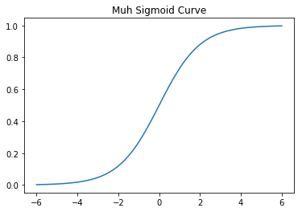

```python
foo = np.linspace(-6,6,100)
bar = [sigmoid_activation(Z) for Z in foo]
_ = plt.plot(foo, bar)
_ = plt.title('Muh Sigmoid Curve')
```

```python
# Activation function on ouput will be the identity function:

def identity_activation(Z):
    '''Super duper complex activation function. Not for Neural Network N00bs.'''
    return(Z)
```

```python
# Find weights and biases to approximate step function. We use a high weight, of 500, to approximate the step function.

def solve_for_bias(s, w=500):
    return(-w * s)
```

```python
# Set up model architecture and define the weights and biases.
# Weights and biases for hidden layer
steps = [0,.2,.2,.4,.4,.6,.6,.8,.8,1]
bias_hl = np.array([solve_for_bias(s) for s in steps])
weights_hl = np.array([500] * 10)

# Weights and biases for output node
bias_output = 0
weights_output = np.array([-1.2, 1.2, -1.6, 1.6, -.3, .3, -1, 1, 1, -1])
# These come just from our values of h
```

```python
# Define function to run the network:
def run_network(x, activation_on_output=identity_activation):
    input_value = x
    Z_hl = input_value * weights_hl + bias_hl
    activation_hl = np.array([sigmoid_activation(Z) for Z in Z_hl])

    Z_output = np.sum(activation_hl * weights_output) + bias_output
    activation_output = activation_on_output(Z_output) # Very complex and vital step here.
    return(activation_output)
```

**Problem 7**: Once you've built the neural network, use `np.linspace` to generate 1000 values of $x$ between 0 and 1 and use and `pynverse` [library](https://pypi.python.org/pypi/pynverse) to help estimate the performance of your neural network using mean squared error.

Recall that mean squared error is given by:

$$ \frac{1}{n}\sum_{i=1}^n (\hat{y}-y)^2 $$

- Your $\hat{y}$ in this case are your predicted values from your neural network for each of the $x$ that you generated using `np.linspace`.
- Your $y$ values are the actual observed values of $f(x)=0.2+0.4x^2+0.3x\sin(15x)+0.05\cos(50x)$ for each of the $x$ that you generated using `np.linspace`.

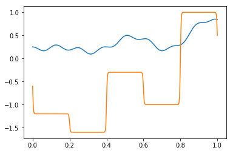

```python
x_values = np.linspace(0,1,1000)
y_hat = [run_network(x) for x in x_values]

def f(x):
    return(.2 + .4*(x**2) + .3*x*np.sin(15*x)+.05*np.cos(50*x))

y = [f(x) for x in x_values]

_ = plt.plot(x_values, y)
_ = plt.plot(x_values, y_hat)
```

Oops! I though we were supposed to build the model from our work in problem 5, which was to approximate `f(x)*`, not `f(x)`. Recall that `f(x)* = sigma_inverse(f(x))` for some activation function sigma. So just using our `h` values won't work.

Maybe Nielsen could have been clearer that sigma was just the sigmoid function. So we use pynverse to find the inverse of our defined sigmoid function, and apply it to our y values:

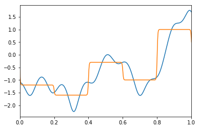

```python
from pynverse import inversefunc
inv_sigmoid = inversefunc(sigmoid_activation)

y_hat = [run_network(x) for x in x_values]
y_invsig = [inv_sigmoid(i) for i in y]
_ = plt.plot(x_values, y_invsig)
_ = plt.plot(x_values, y_hat)
_ = plt.xlim((0,1))
```

Or we can can just use the sigmoid activation on our output node, which makes more sense. Also means we don't need the pynverse library.

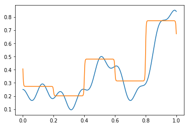

```python
y_hat = [run_network(x, activation_on_output = sigmoid_activation) for x in x_values]

_ = plt.plot(x_values, y)
_ = plt.plot(x_values, y_hat)

# Boom!
```

```python
def my_MSE(y_hat, y):
    if len(y_hat) != len(y):
        print('y_hat and y must be of equal length!')
        return
    n   = len(y_hat)
    SE  = [(y_hat[i] - y[i])**2 for i in range(n)]
    MSE = sum(SE)/n
    return(MSE)
```

```python
my_MSE(y_hat, y) # Not too shabby.
```

```
0.014210204010473139
```

**Problem 8**: Suppose you wanted to increase the performance of this neural network. How might you go about doing so?

Backpropagation! It is magic. I don't know how it works, exactly.

But in the case of this exact network, we are really only tuning 5 parameters: our `h` values. We could run some optimization algorithm (gradient descent, maybe?) to find optimal values of `h` and thus optimal values of `w`. We would be minimizing MSE. Or we could be sassy and minimize RMSE.

More simply, you could just set the value of `h` for each 'bump' to be equal to the mean of `f(x)*` for (0,.2), (.2,.4), etc:

```python
def mean_f(start, stop):
    return(np.mean([inv_sigmoid(f(x)) for x in np.linspace(start, stop, 100)]))
```

```python
h1 = mean_f(0,.2)
h2 = mean_f(.2, .4)
h3 = mean_f(.4,.6)
h4 = mean_f(.6,.8)
h5 = mean_f(.8,1)
```

```python
weights_output=[h1,-h1, h2,-h2, h3,-h3, h4,-h4, h5,-h5]
y_hat = [run_network(x, activation_on_output = sigmoid_activation) for x in x_values]
my_MSE(y_hat, y) # Sho enuf. The MSE goes down!
```

```
0.01185382546457326
```

If I interpret 'this network' a little more liberally, I woud assume the network is still basically the same* if it has 20 nodes in the hidden layer, instead of 10. This network would produce an approximation with 10 'bumps', rather than just 5. Therefore it would achieve more granularity in approximating a complex function and would perform much better. Lets try.

*The famous [Network of Theseus Problem](https://en.wikipedia.org/wiki/Ship_of_Theseus)

```python
h_values = []
for i in np.linspace(0,.9,10):
    h_values.append(mean_f(i, i+.1))
weights_output = [j for i in zip(h_values, [-1*i for i in h_values]) for j in i]
```

```python
steps = [0,.1,.1,.2,.2,.3,.3,.4,.4,.5,.5,.6,.6,.7,.7,.8,.8,.9,.9,1]
bias_hl = np.array([solve_for_bias(s) for s in steps])
weights_hl = np.array([500] * 20)
bias_output = 0
```

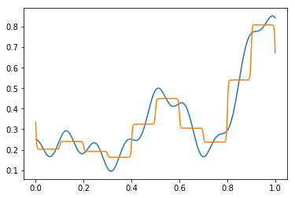

```python
y_hat = [run_network(x, activation_on_output = sigmoid_activation) for x in x_values]

_ = plt.plot(x_values, y)
_ = plt.plot(x_values, y_hat)
```

```python
my_MSE(y_hat, y) # The MSE is less than half than our best network with only 5 bumps!
```

```
0.0049425616606165084
```

Why don't we just go ahead and generalize this to any number of bumps? It won't be pretty:

```python
# Re-write our mean of f(x)* function so it accepts a tuple input
def mean_f(range):
    start, stop = range
    return(np.mean([inv_sigmoid(f(x)) for x in np.linspace(start, stop, 100)]))
```

```python
def my_humps_my_humps(num_bumps):
    steps = np.linspace(0,1,num_bumps+1)
    bumps = zip(steps[:-1],steps[1:])

    h_values = [mean_f(tup) for tup in bumps]

    weights_output = [j for i in zip(h_values, [-1*i for i in h_values]) for j in i]

    steps = list(steps)
    start = steps.pop(0)
    stop  = steps.pop(-1)
    steps = steps * 2
    steps.append(start)
    steps.append(stop)
    steps = sorted(steps)

    bias_hl = np.array([solve_for_bias(s) for s in steps])
    weights_hl = np.array([500] * (num_bumps*2))
    bias_output = 0
    return(weights_hl, bias_hl, weights_output, bias_output)
```

```
MSE: 0.000350520985657
```

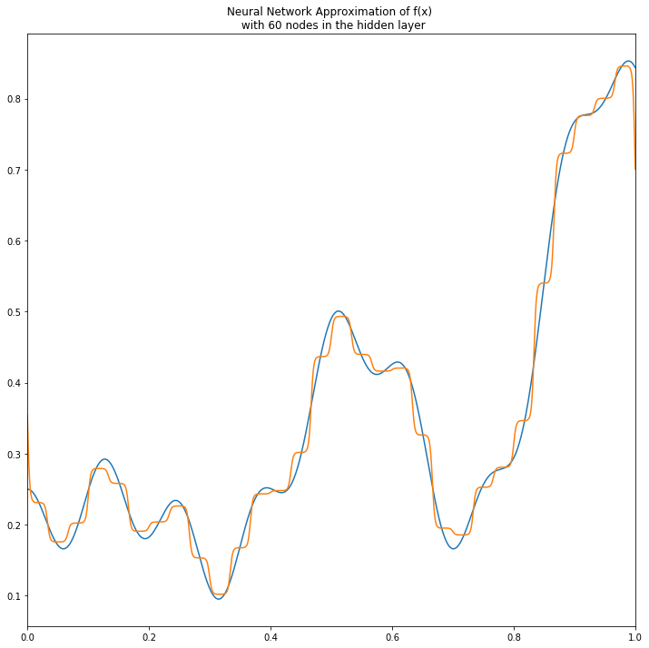

```python
weights_hl, bias_hl, weights_output, bias_output = my_humps_my_humps(30)
y_hat = [run_network(x, activation_on_output = sigmoid_activation) for x in x_values]

print('MSE: ' + str(my_MSE(y_hat, y)))

_ = plt.figure(figsize=(12,12))
_ = plt.plot(x_values, y)
_ = plt.plot(x_values, y_hat)
_ = plt.title('Neural Network Approximation of f(x) \n with 60 nodes in the hidden layer')
_ = plt.xlim((0,1))
```